# 岭回归中的偏差—方差权衡

一份模板演示：数学、图表、代码与交叉引用

Mainsub

中国科学技术大学

2026 年 10 月 10 日

摘要

本文以岭回归为例演示模板的排版效果。我们在高斯线性模型下推导岭估计量的偏差与方差，说明适度的收缩如何以少量偏差换取方差的显著下降，并用一个模拟实验验证这一结论。

关键词岭回归；偏差—方差分解；收缩估计

# 1 引言

当设计矩阵 $X$ 的列高度相关时，最小二乘估计 $\hat\beta = (X^\top X)^{-1}X^\top y$ 的方差会急剧膨胀。Hoerl 等 (1970) 提出在 $X^\top X$ 的对角线上加入一个正常数，以*牺牲无偏性为代价*换取更稳定的估计；这一思想后来成为收缩估计（shrinkage estimation）的基石 (Hastie 等, 2009)。关于线性模型的经典理论，可参考 陈希孺 (1999)。[^1]

本文的结构如下：第 2 节给出模型与估计量，第 3 节给出数值示例。

# 2 模型与估计量

## 2.1 设定

**定义 1 (高斯线性模型)** 观测满足 $y = X\beta + \varepsilon$，其中 $X\in\mathbb{R}^{n\times p}$ 为固定设计，$\varepsilon \sim \mathcal{N}(0, \sigma^2 I_n)$。

**定义 2 (岭估计量)** 对给定的 $\lambda > 0$，岭估计量定义为
$$\begin{equation}
\hat\beta_\lambda
= \operatorname*{arg\,min}_{b\in\mathbb{R}^p} \Bigl\{ \lVert y - Xb \rVert_2^2 + \lambda \lVert b \rVert_2^2 \Bigr\}
= (X^\top X + \lambda I_p)^{-1} X^\top y .
\tag{1}
\end{equation}$$

## 2.2 偏差与方差

记 $X = UDV^\top$ 为奇异值分解，$d_1\ge\cdots\ge d_p>0$ 为奇异值。

**命题 1** 在定义 1 下，岭估计量的偏差与协方差分别为
$$\begin{align}
\operatorname{Bias}(\hat\beta_\lambda) &= -\lambda\,(X^\top X + \lambda I_p)^{-1}\beta, \tag{2}\\
\operatorname{Var}(\hat\beta_\lambda) &= \sigma^2 \sum_{j=1}^{p} \frac{d_j^2}{(d_j^2+\lambda)^2}\, v_j v_j^\top . \tag{3}
\end{align}$$
因此 $\operatorname{tr}\operatorname{Var}(\hat\beta_\lambda)$ 关于 $\lambda$ 严格递减，而当 $\beta\neq0$ 时 $\lVert \operatorname{Bias}(\hat\beta_\lambda) \rVert_2^2$ 严格递增。

*Proof*. 由式 (1) 及 $\mathbb{E} y = X\beta$ 得 $\mathbb{E}\hat\beta_\lambda = (X^\top X+\lambda I)^{-1}X^\top X\beta$，两边减去 $\beta$ 即得式 (2)。又 $\operatorname{Var}(y)=\sigma^2 I_n$，代入奇异值分解 $(X^\top X+\lambda I)^{-1}X^\top = V\operatorname{diag}\bigl(d_j/(d_j^2+\lambda)\bigr)U^\top$ 即得式 (3)。

*Remark*. 当 $\lambda\to0$ 时 $\hat\beta_\lambda$ 收敛到最小二乘估计；当 $\lambda\to\infty$ 时 $\hat\beta_\lambda\to0$。均方误差 $\operatorname{MSE}(\lambda) = \lVert \operatorname{Bias} \rVert_2^2 + \operatorname{tr}\operatorname{Var}$ 在两者之间取得最小值。

# 3 数值示例

我们取 $n=120$、$p=6$，设计矩阵的行独立服从 $\mathcal{N}(0,\Sigma)$，其中 $\Sigma_{ij}=0.6^{\lvert i-j \rvert}$，真实系数 $\beta=(2,-1.5,1,0,0,0.5)^\top$，$\sigma=2$。图 1 给出系数随 $\lambda$ 的收缩路径，表 1 给出由式 (2) 与式 (3) 精确计算的风险分解。

**代码**

```r
n <- 120; p <- 6; sigma <- 2
Sigma <- 0.6^abs(outer(1:p, 1:p, "-"))
X <- matrix(rnorm(n * p), n) %*% chol(Sigma)
beta <- c(2, -1.5, 1, 0, 0, 0.5)
y <- X %*% beta + rnorm(n, sd = sigma)
```

**代码**

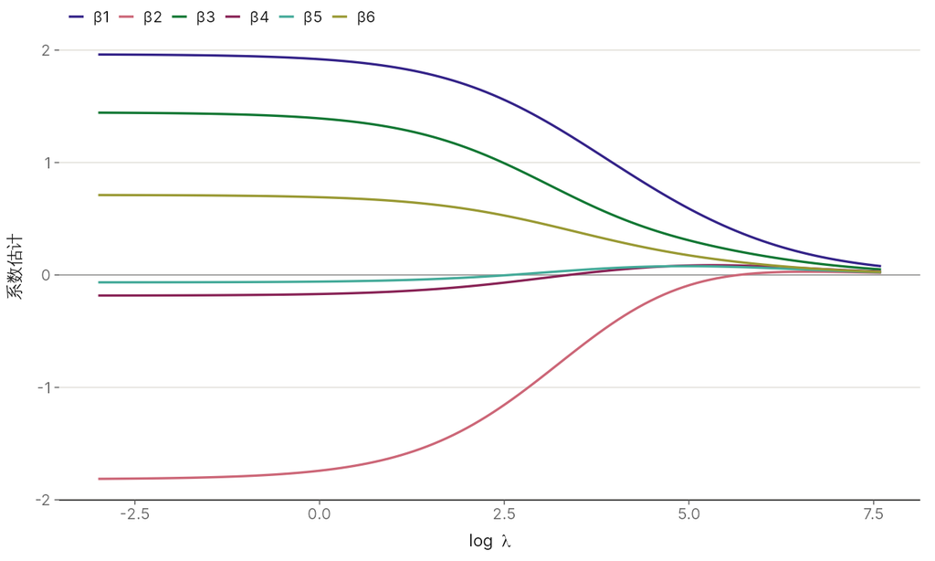

图 1: 岭回归的系数路径。随着 $\lambda$ 增大，所有系数被连续地压向零。

```r
lam <- exp(seq(log(0.05), log(2000), length.out = 120))
B <- sapply(lam, function(l) solve(crossprod(X) + l * diag(p), crossprod(X, y)))
paths <- data.frame(loglam = rep(log(lam), each = p), coef = as.vector(B),
                    j = factor(rep(paste0("β", 1:p), times = length(lam))))
ggplot(paths, aes(loglam, coef, colour = j)) +
  geom_hline(yintercept = 0, colour = "grey60", linewidth = 0.3) +
  geom_line(linewidth = 0.6) +
  labs(x = expression(log ~ lambda), y = "系数估计", colour = NULL) +
  guides(colour = guide_legend(nrow = 1))
```

**代码**

```r
risk <- function(l) {
  A <- solve(crossprod(X) + l * diag(p))
  b <- -l * A %*% beta
  v <- sum(diag(sigma^2 * A %*% crossprod(X) %*% A))
  c(lambda = l, bias2 = sum(b^2), var = v, mse = sum(b^2) + v)
}
tab <- as.data.frame(t(sapply(c(0, 1, 2, 5, 20, 100), risk)))
knitr::kable(tab, format = "pipe", digits = 3, align = "r",
             caption = "不同 $\\lambda$ 下的偏差、方差与均方误差",
             col.names = c("$\\lambda$", "$\\norm{\\Bias}_2^2$", "$\\tr\\Var$", "$\\MSE$"))
```

表 1: 不同 $\lambda$ 下的偏差、方差与均方误差

| $\lambda$ | $\lVert \operatorname{Bias} \rVert_2^2$ | $\operatorname{tr}\operatorname{Var}$ | $\operatorname{MSE}$ |
| --- | --- | --- | --- |
| 0 | 0.000 | 0.449 | 0.449 |
| 1 | 0.008 | 0.424 | 0.432 |
| 2 | 0.029 | 0.402 | 0.430 |
| 5 | 0.148 | 0.345 | 0.493 |
| 20 | 1.110 | 0.194 | 1.305 |
| 100 | 4.030 | 0.048 | 4.078 |

从表 1 可以读出：方差随 $\lambda$ 单调下降，偏差单调上升，与命题 1 一致；适度的收缩使 MSE 低于最小二乘（$\lambda=0$），而过度收缩则让偏差主导风险。

计算岭估计量只需要一行线性代数：

**代码**

```r
ridge <- function(X, y, lambda) {
  p <- ncol(X)
  solve(crossprod(X) + lambda * diag(p), crossprod(X, y))  # 求解正规方程
}
```

# 4 结论

岭回归说明了统计学中一个反复出现的主题：*无偏并不等于好*。在实践中，$\lambda$ 通常由交叉验证选取。

# 参考文献

Hastie T, Tibshirani R, Friedman J, 2009. The Elements of Statistical Learning: Data Mining, Inference, and Prediction[M/OL]. 2 版. New York: Springer. DOI:10.1007/978-0-387-84858-7.

Hoerl A E, Kennard R W, 1970. Ridge Regression: Biased Estimation for Nonorthogonal Problems[J/OL]. Technometrics, 12(1): 55-67. DOI:10.1080/00401706.1970.10488634.

陈希孺, 1999. 高等数理统计学[M]. 合肥: 中国科学技术大学出版社.

[^1]: 本文所有数值结果均可由文中代码复现。